# West States Correlations

In this markdown I will look at each of the features and run correlations on them to see how they relate with poverty proportion. I will also graph out each one of them to get a visual on the relationship.

I am going to first load in the project data that was prepared and then take a look at it.

```r
library(tidyverse)
project_data <- read_csv("west_data.csv")
project_data
```

| X1 | Unnamed: 0 | ID | Lea State.x | LEA.x | Area_Population | Children_Poverty | Poverty_Proportion | Student_Prop | District_Population | Non_White_Students | New_Teachers_Proportion | Absent_Teacher_Proportion | Counselor_Ratio | Student_Teacher_Ratio | Absent_Prop | Test_Prop | Teams_Prop | Athletes_Prop | Takers_Proportion | AP_Prop | AVG_Suspenion | Expulsion_Prop | Police_Prop | Race_Disc | Race_Reports | Gender_Disc | Gender_Reports | Alg1 | Alg2 | … |
| --- | --- | --- | --- | --- | --- | --- | --- | --- | --- | --- | --- | --- | --- | --- | --- | --- | --- | --- | --- | --- | --- | --- | --- | --- | --- | --- | --- | --- | --- | --- |
| 124 | 125 | 200050 | AK | Alaska Gateway School District | 2295 | 85 | 0.21250000 | 0.17298475 | 397 | 0.670025189 | 0.058823529 | 0.000000000 | 2.518892e-03 | 11.676471 | 0.206549118 | 0.0025188917 | 0.0075566751 | 0.1385390428 | 0.00000000 | 0.0075566751 | 0.0327455919 | 0.000000e+00 | 0.000000e+00 | 0.000000e+00 | 0.000000e+00 | 0.000000e+00 | 0.000000e+00 | 1.763224e-02 | 5.037783e-03 | … |
| 125 | 126 | 200007 | AK | Aleutians East Borough School District | 3370 | 22 | 0.10679612 | 0.06172107 | 208 | 0.903846154 | 0.133333333 | 0.000000000 | 0.000000e+00 | 6.933333 | 0.288461538 | 0.0625000000 | 0.0288461538 | 0.3173076923 | 0.00000000 | 0.0000000000 | 0.0096153846 | 0.000000e+00 | 0.000000e+00 | 0.000000e+00 | 0.000000e+00 | 0.000000e+00 | 0.000000e+00 | 1.442308e-02 | 1.442308e-02 | … |
| 126 | 127 | 200180 | AK | Anchorage School District | 294356 | 5553 | 0.10974959 | 0.16099213 | 47389 | 0.582308131 | 0.094494793 | 0.493749272 | 2.013547e-03 | 22.080936 | 0.252632467 | 0.0365063622 | 0.0050644664 | 0.1495705754 | 0.71985971 | 0.0481335331 | 0.0443351833 | 2.743253e-04 | 1.160607e-03 | 1.055097e-03 | 1.329422e-03 | 2.468927e-03 | 3.397413e-03 | 3.418515e-03 | 2.046889e-03 | … |
| 127 | 128 | 200525 | AK | Annette Island School District | 1525 | 54 | 0.19217082 | 0.21245902 | 324 | 0.944444444 | 0.586206897 | 0.034482759 | 9.259259e-03 | 11.172414 | 0.339506173 | 0.0000000000 | 0.0185185185 | 0.1234567901 | 0.00000000 | 0.0000000000 | 0.2006172840 | 0.000000e+00 | 0.000000e+00 | 0.000000e+00 | 0.000000e+00 | 0.000000e+00 | 0.000000e+00 | 6.172840e-03 | 0.000000e+00 | … |
| 128 | 129 | 200020 | AK | Bering Strait School District | 6164 | 522 | 0.30651791 | 0.32478910 | 2002 | 0.993506494 | 0.130000000 | 0.020000000 | 3.986014e-03 | 10.010000 | 0.436063936 | 0.0129870130 | 0.0000000000 | 0.0000000000 | 0.00000000 | 0.0000000000 | 0.2952047952 | 0.000000e+00 | 7.992008e-03 | 0.000000e+00 | 0.000000e+00 | 4.995005e-04 | 4.995005e-04 | 6.993007e-03 | 4.495504e-03 | … |
| 129 | 130 | 200030 | AK | Bristol Bay Borough School District | 867 | 22 | 0.19469027 | 0.13840830 | 120 | 0.700000000 | 0.181488203 | 0.045372051 | 8.333333e-03 | 10.889292 | 0.291666667 | 0.1250000000 | 0.1000000000 | 0.4250000000 | 0.00000000 | 0.0000000000 | 0.0916666667 | 0.000000e+00 | 1.666667e-02 | 0.000000e+00 | 0.000000e+00 | 0.000000e+00 | 0.000000e+00 | 1.666667e-02 | 8.333333e-03 | … |
| 130 | 131 | 200730 | AK | Chatham School District | 1291 | 48 | 0.25945946 | 0.13632843 | 176 | 0.642045455 | 0.055555556 | 0.000000000 | 0.000000e+00 | 9.777778 | 0.335227273 | 0.0397727273 | 0.0170454545 | 0.1306818182 | 0.00000000 | 0.0000000000 | 0.0284090909 | 0.000000e+00 | 0.000000e+00 | 0.000000e+00 | 0.000000e+00 | 0.000000e+00 | 0.000000e+00 | 1.704545e-02 | 2.272727e-02 | … |
| 131 | 132 | 200800 | AK | Chugach School District | 451 | 20 | 0.34482759 | 0.98447894 | 444 | 0.322072072 | 0.153846154 | 0.000000000 | 0.000000e+00 | 34.153846 | 0.058558559 | 0.0292792793 | 0.0000000000 | 0.0000000000 | 0.00000000 | 0.0000000000 | 0.1463963964 | 0.000000e+00 | 0.000000e+00 | 0.000000e+00 | 0.000000e+00 | 0.000000e+00 | 0.000000e+00 | 1.801802e-02 | 1.801802e-02 | … |
| 132 | 133 | 200070 | AK | Copper River School District | 2721 | 88 | 0.18723404 | 0.16464535 | 448 | 0.477678571 | 0.242424242 | 0.040404040 | 4.464286e-03 | 18.101010 | 0.310267857 | 0.0200892857 | 0.0000000000 | 0.0000000000 | 0.80000000 | 0.0223214286 | 0.1026785714 | 0.000000e+00 | 4.464286e-03 | 0.000000e+00 | 0.000000e+00 | 0.000000e+00 | 0.000000e+00 | 1.116071e-02 | 2.232143e-03 | … |
| 133 | 134 | 200090 | AK | Craig City School District | 1254 | 55 | 0.23605150 | 0.43460925 | 545 | 0.385321101 | 0.188366588 | 0.392289483 | 7.339450e-04 | 18.430842 | 0.130275229 | 0.0366972477 | 0.0000000000 | 0.0000000000 | 0.63157895 | 0.0348623853 | 0.0201834862 | 5.504587e-03 | 0.000000e+00 | 0.000000e+00 | 0.000000e+00 | 0.000000e+00 | 0.000000e+00 | 5.504587e-03 | 3.669725e-03 | … |

[output cut: 1084 more lines]

Look at a plot of poverty compared to new teacher.

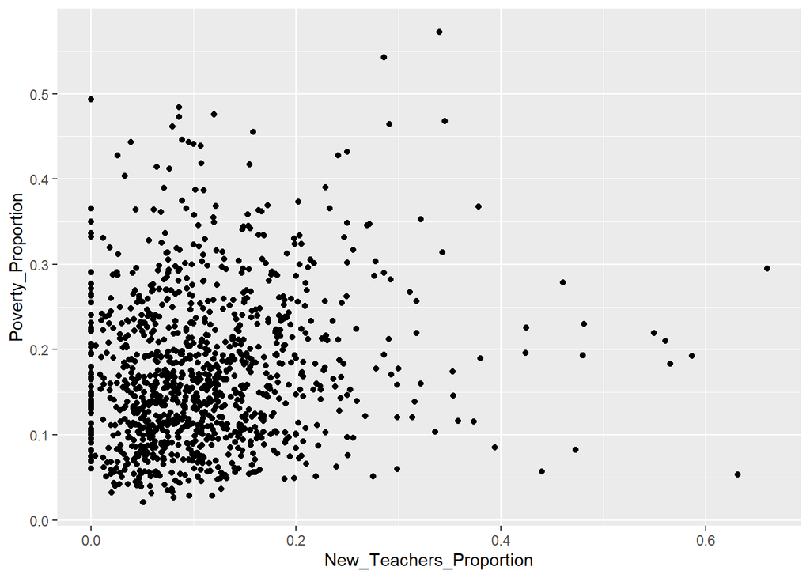

```r
project_data %>%
  ggplot(aes(New_Teachers_Proportion, Poverty_Proportion)) +
  geom_point()
```

I am going to look at the correlation for new teachers.

```r
cor.test(project_data$New_Teachers_Proportion, project_data$Poverty_Proportion)
```

```
##
##  Pearson's product-moment correlation
##
## data:  project_data$New_Teachers_Proportion and project_data$Poverty_Proportion
## t = 5.4656, df = 1092, p-value = 5.716e-08
## alternative hypothesis: true correlation is not equal to 0
## 95 percent confidence interval:
##  0.1049242 0.2203163
## sample estimates:
##       cor
## 0.1631783
```

I am going to graph out absent teacher ratio to see the relationship.

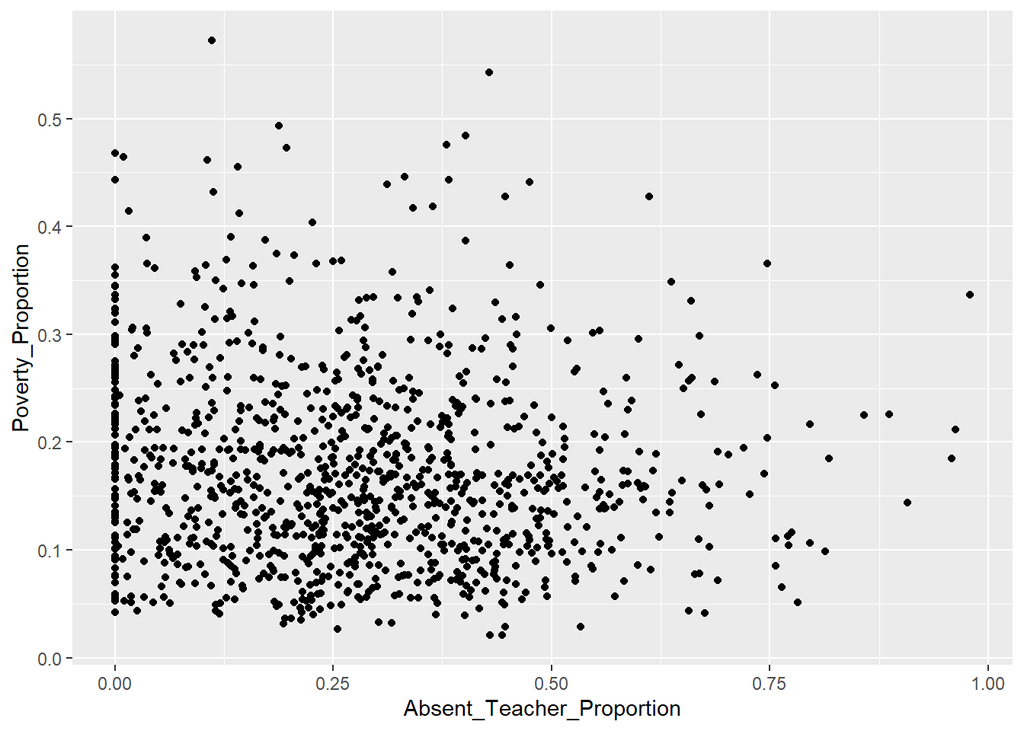

```r
project_data %>%
  ggplot(aes(Absent_Teacher_Proportion, Poverty_Proportion)) +
  geom_point()
```

Looking at the correlation between for absent teachers.

```r
cor.test(project_data$Absent_Teacher_Proportion, project_data$Poverty_Proportion)
```

```
##
##  Pearson's product-moment correlation
##
## data:  project_data$Absent_Teacher_Proportion and project_data$Poverty_Proportion
## t = -2.6643, df = 1092, p-value = 0.007829
## alternative hypothesis: true correlation is not equal to 0
## 95 percent confidence interval:
##  -0.13897047 -0.02119567
## sample estimates:
##         cor
## -0.08036355
```

Looking at the graph of counselor ratio.

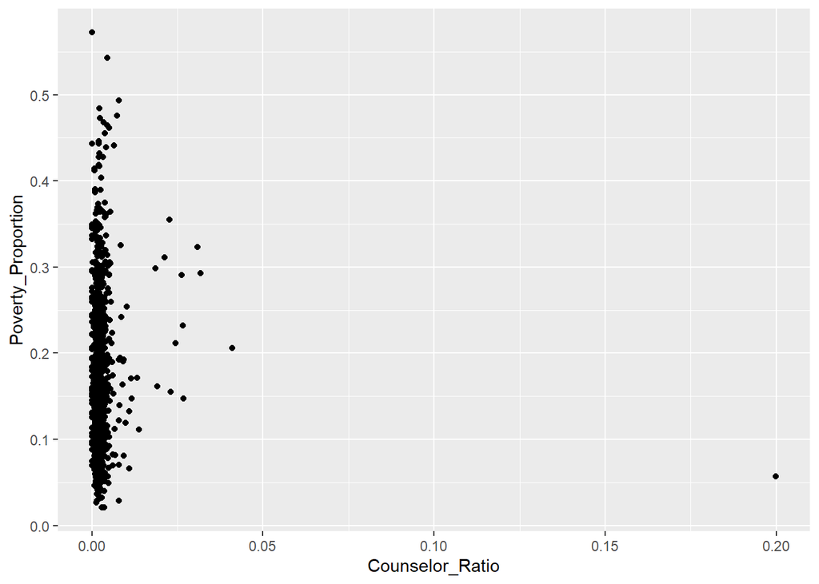

```r
project_data %>%
  ggplot(aes(Counselor_Ratio, Poverty_Proportion)) +
  geom_point()
```

Look at the correlation for counselor ratio.

```r
cor.test(project_data$Counselor_Ratio, project_data$Poverty_Proportion)
```

```
##
##  Pearson's product-moment correlation
##
## data:  project_data$Counselor_Ratio and project_data$Poverty_Proportion
## t = 0.066778, df = 1092, p-value = 0.9468
## alternative hypothesis: true correlation is not equal to 0
## 95 percent confidence interval:
##  -0.05725491  0.06128229
## sample estimates:
##         cor
## 0.002020788
```

Looking at the graph with the student_teacher_ratio.

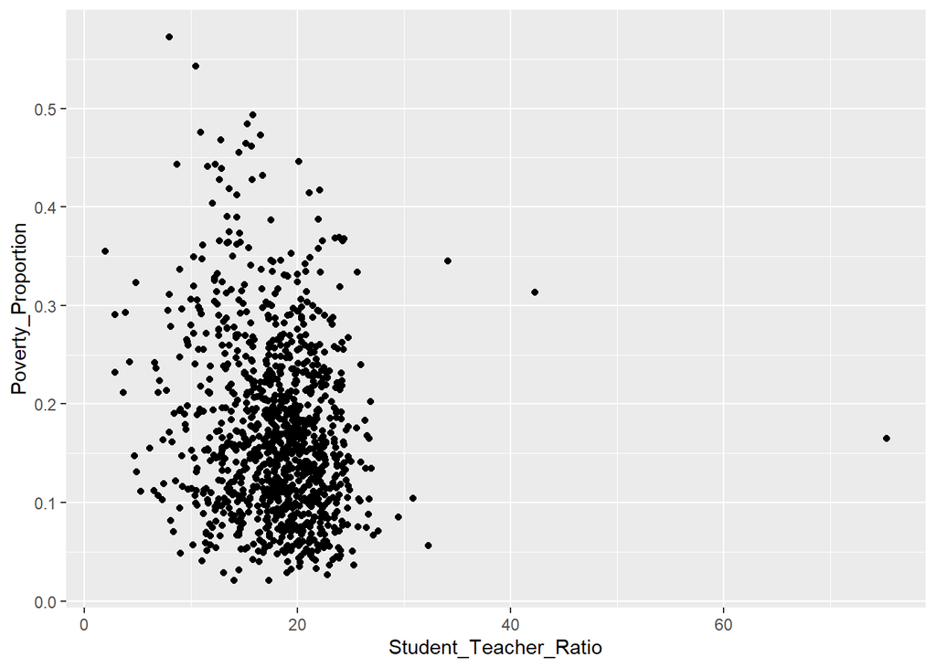

```r
project_data %>%
  ggplot(aes(Student_Teacher_Ratio, Poverty_Proportion)) +
  geom_point()
```

Looking at the correlation with student teacher ratio.

```r
cor.test(project_data$Student_Teacher_Ratio, project_data$Poverty_Proportion)
```

```
##
##  Pearson's product-moment correlation
##
## data:  project_data$Student_Teacher_Ratio and project_data$Poverty_Proportion
## t = -5.6469, df = 1092, p-value = 2.083e-08
## alternative hypothesis: true correlation is not equal to 0
## 95 percent confidence interval:
##  -0.2254584 -0.1102724
## sample estimates:
##        cor
## -0.1684404
```

Looking at how chronic abseentism graphs with poverty.

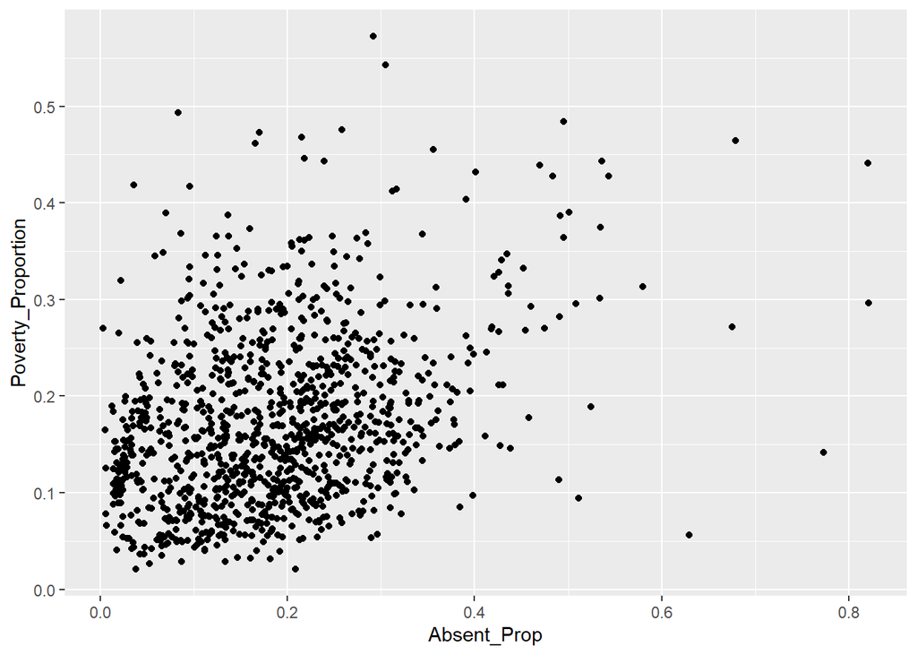

```r
project_data %>%
  ggplot(aes(Absent_Prop, Poverty_Proportion)) +
  geom_point()
```

Looking at the correlation for absent and poverty.

```r
cor.test(project_data$Absent_Prop, project_data$Poverty_Proportion)
```

```
##
##  Pearson's product-moment correlation
##
## data:  project_data$Absent_Prop and project_data$Poverty_Proportion
## t = 12.094, df = 1092, p-value < 2.2e-16
## alternative hypothesis: true correlation is not equal to 0
## 95 percent confidence interval:
##  0.2903421 0.3949207
## sample estimates:
##       cor
## 0.3436966
```

Looking at the graph of students that have taken the SAT or ACT compared to poverty.

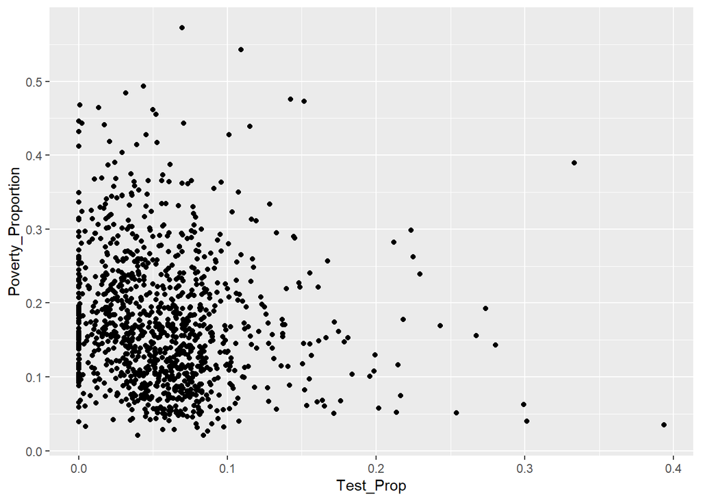

```r
project_data %>%
  ggplot(aes(Test_Prop, Poverty_Proportion)) +
  geom_point()
```

Look at the correlation of test takers.

```r
cor.test(project_data$Test_Prop, project_data$Poverty_Proportion)
```

```
##
##  Pearson's product-moment correlation
##
## data:  project_data$Test_Prop and project_data$Poverty_Proportion
## t = -4.0406, df = 1092, p-value = 5.705e-05
## alternative hypothesis: true correlation is not equal to 0
## 95 percent confidence interval:
##  -0.17934865 -0.06255107
## sample estimates:
##      cor
## -0.12137
```

Looking at how sports team relates to poverty.

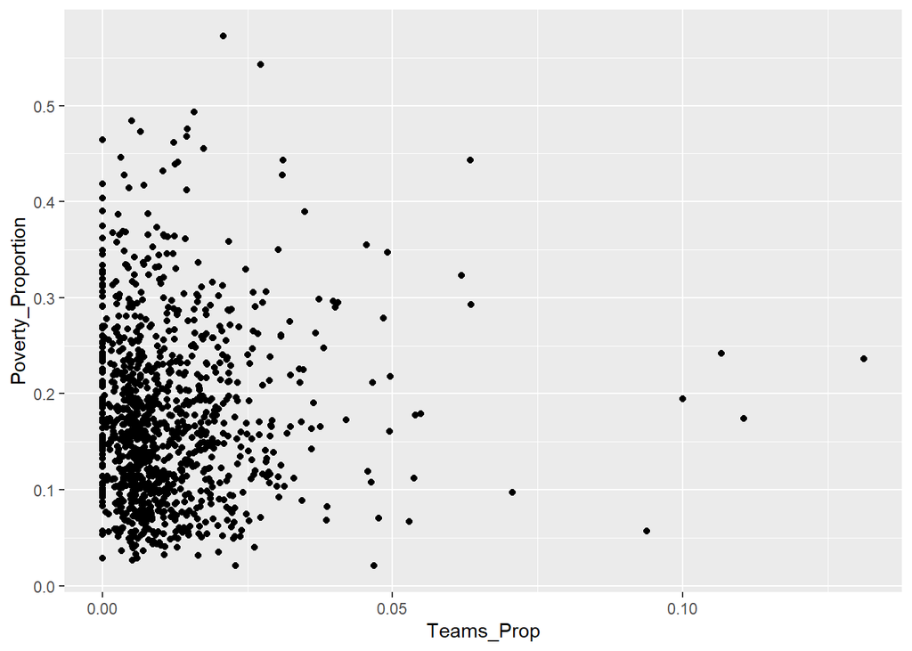

```r
project_data %>%
  ggplot(aes(Teams_Prop, Poverty_Proportion)) +
  geom_point()
```

Looking at the correlation of teams to poverty.

```r
cor.test(project_data$Teams_Prop, project_data$Poverty_Proportion)
```

```
##
##  Pearson's product-moment correlation
##
## data:  project_data$Teams_Prop and project_data$Poverty_Proportion
## t = 1.616, df = 1092, p-value = 0.1064
## alternative hypothesis: true correlation is not equal to 0
## 95 percent confidence interval:
##  -0.01045596  0.10779992
## sample estimates:
##        cor
## 0.04884315
```

Looking at athletes compared to poverty.

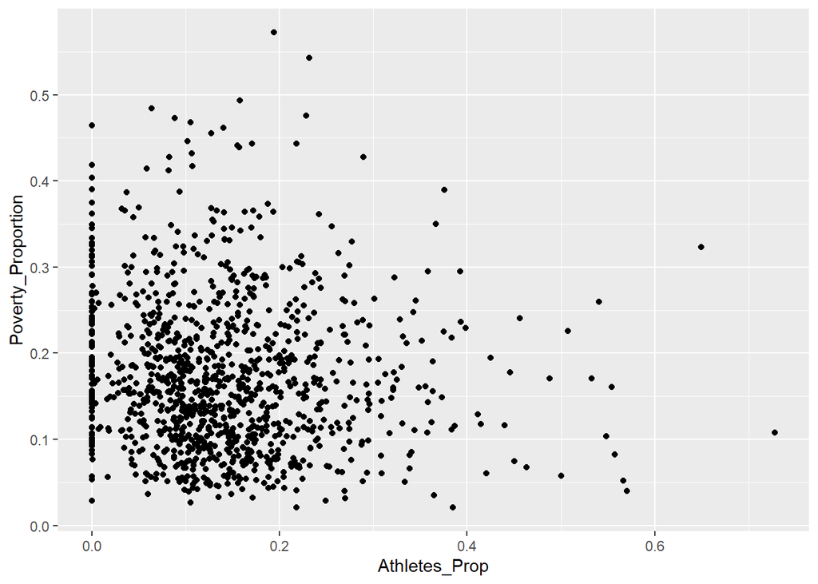

```r
project_data %>%
  ggplot(aes(Athletes_Prop, Poverty_Proportion)) +
  geom_point()
```

Looking at the correlation of athletes.

```r
cor.test(project_data$Athletes_Prop, project_data$Poverty_Proportion)
```

```
##
##  Pearson's product-moment correlation
##
## data:  project_data$Athletes_Prop and project_data$Poverty_Proportion
## t = -2.7927, df = 1092, p-value = 0.005318
## alternative hypothesis: true correlation is not equal to 0
## 95 percent confidence interval:
##  -0.14276715 -0.02506715
## sample estimates:
##         cor
## -0.08421087
```

Looking at how ap test takers compare to poverty.

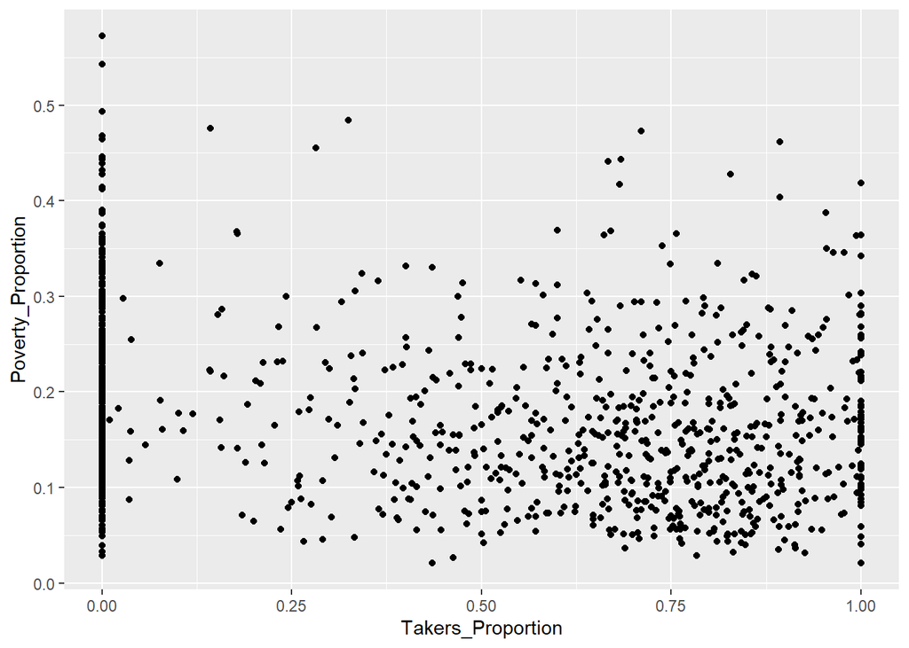

```r
project_data %>%
  ggplot(aes(Takers_Proportion, Poverty_Proportion)) +
  geom_point()
```

Looking at the correlation for the Ap test takers.

```r
cor.test(project_data$Takers_Proportion, project_data$Poverty_Proportion)
```

```
##
##  Pearson's product-moment correlation
##
## data:  project_data$Takers_Proportion and project_data$Poverty_Proportion
## t = -6.7078, df = 1092, p-value = 3.164e-11
## alternative hypothesis: true correlation is not equal to 0
## 95 percent confidence interval:
##  -0.2551912 -0.1413287
## sample estimates:
##        cor
## -0.1989312
```

Looking at AP students compared to poverty.

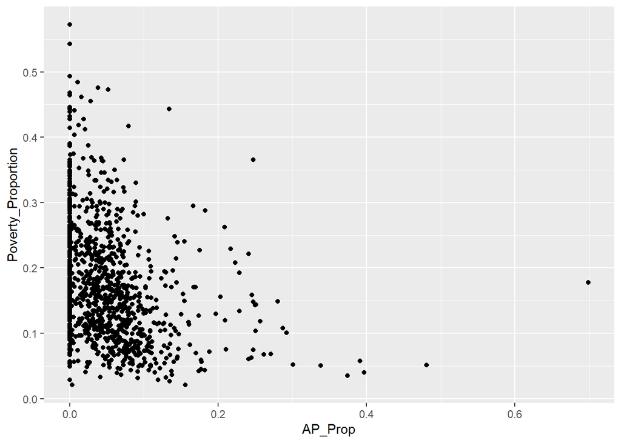

```r
project_data %>%
  ggplot(aes(AP_Prop, Poverty_Proportion)) +
  geom_point()
```

Correlation of AP students to poverty.

```r
cor.test(project_data$AP_Prop, project_data$Poverty_Proportion)
```

```
##
##  Pearson's product-moment correlation
##
## data:  project_data$AP_Prop and project_data$Poverty_Proportion
## t = -10.11, df = 1092, p-value < 2.2e-16
## alternative hypothesis: true correlation is not equal to 0
## 95 percent confidence interval:
##  -0.3458169 -0.2373913
## sample estimates:
##        cor
## -0.2925441
```

Suspension days compared to poverty.

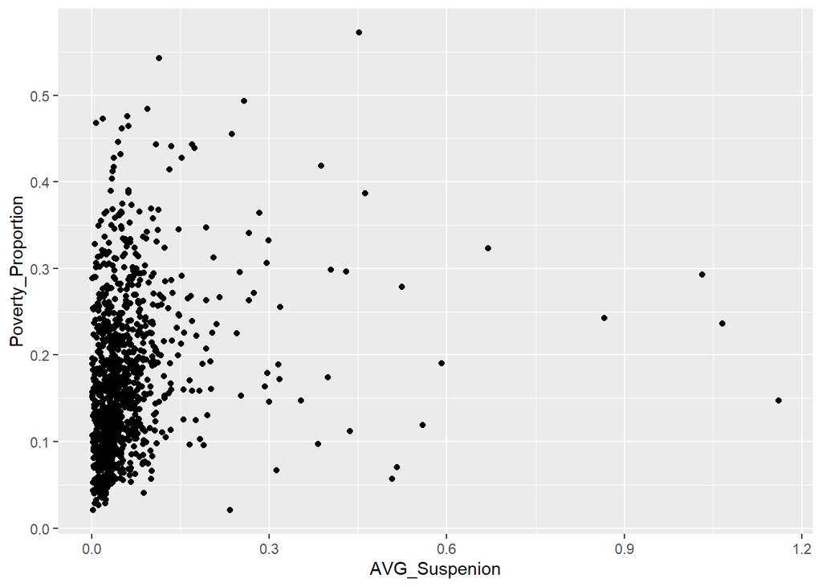

```r
project_data %>%
  ggplot(aes(AVG_Suspenion, Poverty_Proportion)) +
  geom_point()
```

I want to look at the correlation of suspension with poverty.

```r
cor.test(project_data$AVG_Suspenion, project_data$Poverty_Proportion)
```

```
##
##  Pearson's product-moment correlation
##
## data:  project_data$AVG_Suspenion and project_data$Poverty_Proportion
## t = 7.4634, df = 1092, p-value = 1.718e-13
## alternative hypothesis: true correlation is not equal to 0
## 95 percent confidence interval:
##  0.1631663 0.2759700
## sample estimates:
##       cor
## 0.2203046
```

I want to look at expulsions compared to poverty.

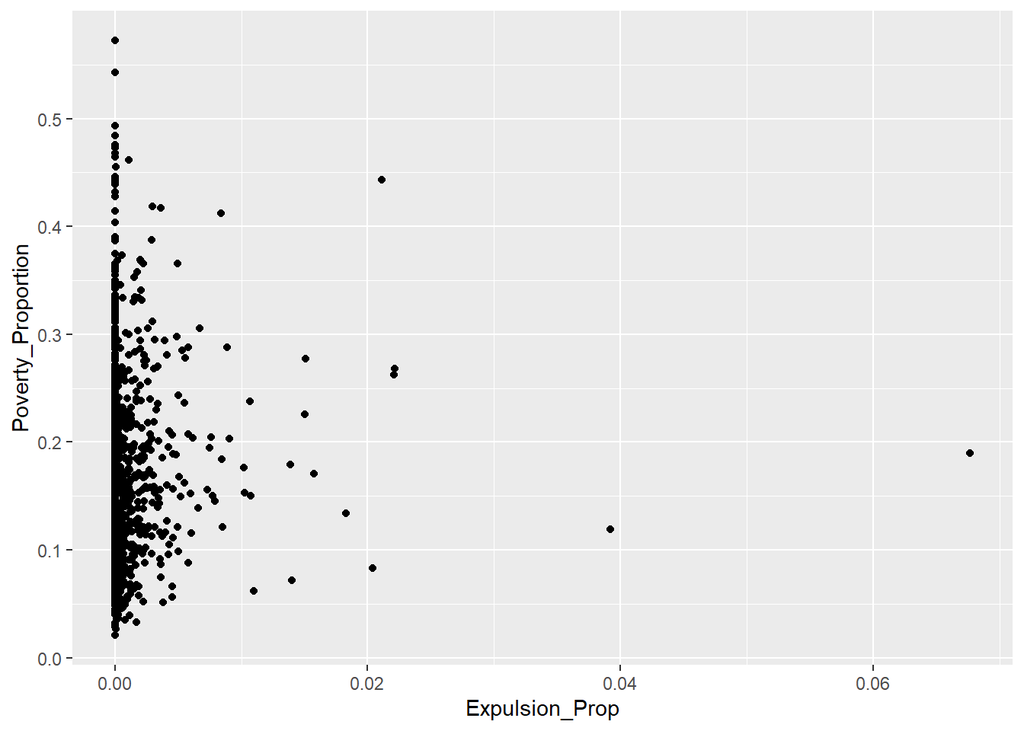

```r
project_data %>%
  ggplot(aes(Expulsion_Prop, Poverty_Proportion)) +
  geom_point()
```

Look at correlation of expulsion to poverty.

```r
cor.test(project_data$Expulsion_Prop, project_data$Poverty_Proportion)
```

```
##
##  Pearson's product-moment correlation
##
## data:  project_data$Expulsion_Prop and project_data$Poverty_Proportion
## t = 1.4814, df = 1092, p-value = 0.1388
## alternative hypothesis: true correlation is not equal to 0
## 95 percent confidence interval:
##  -0.01452312  0.10377764
## sample estimates:
##        cor
## 0.04478426
```

Police involvement compared to poverty.

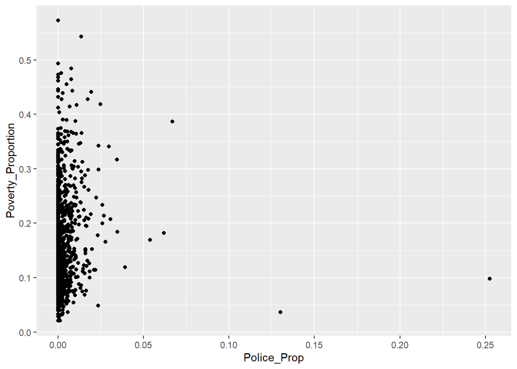

```r
project_data %>%
  ggplot(aes(Police_Prop, Poverty_Proportion)) +
  geom_point()
```

Correlation of police involvement to poverty.

```r
cor.test(project_data$Police_Prop, project_data$Poverty_Proportion)
```

```
##
##  Pearson's product-moment correlation
##
## data:  project_data$Police_Prop and project_data$Poverty_Proportion
## t = 1.5056, df = 1092, p-value = 0.1324
## alternative hypothesis: true correlation is not equal to 0
## 95 percent confidence interval:
##  -0.01379025  0.10450272
## sample estimates:
##        cor
## 0.04551579
```

Student proportion compared to population and poverty.

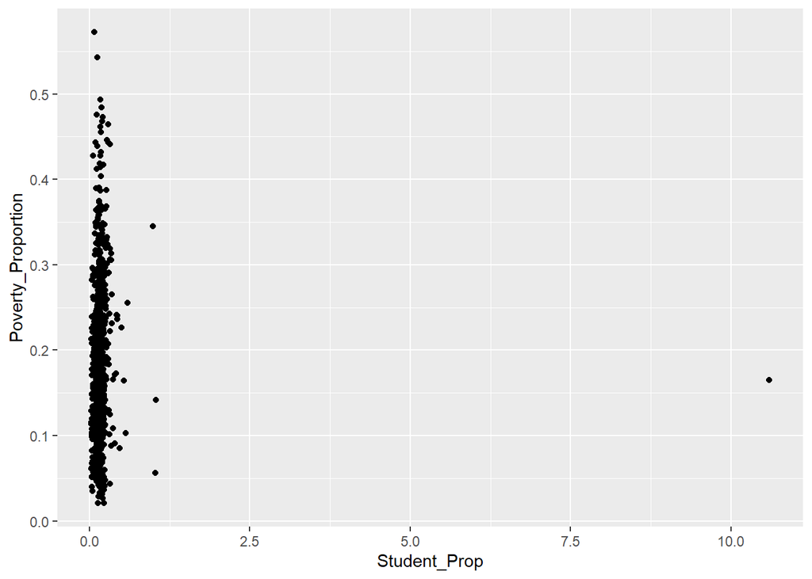

```r
project_data %>%
  ggplot(aes(Student_Prop, Poverty_Proportion)) +
  geom_point()
```

Look at the correlation of the student proportion.

```r
cor.test(project_data$Student_Prop, project_data$Poverty_Proportion)
```

```
##
##  Pearson's product-moment correlation
##
## data:  project_data$Student_Prop and project_data$Poverty_Proportion
## t = 0.67089, df = 1092, p-value = 0.5024
## alternative hypothesis: true correlation is not equal to 0
## 95 percent confidence interval:
##  -0.03901795  0.07947106
## sample estimates:
##        cor
## 0.02029783
```

For the next part I will look at correlations as they relate to bullying on race and gender.

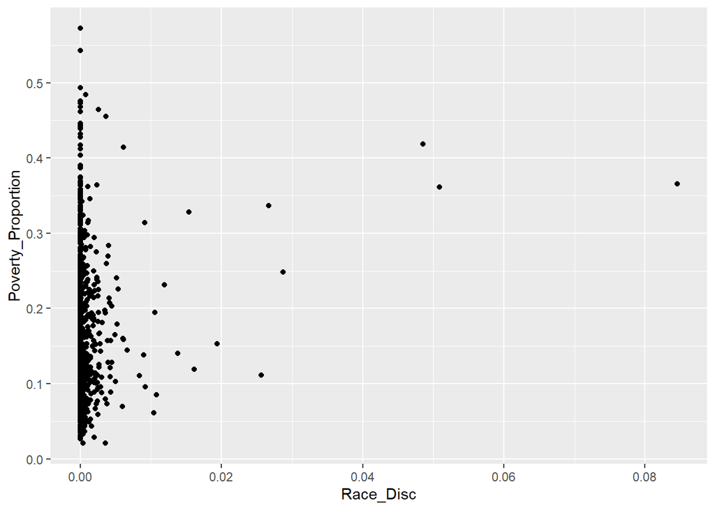

```r
project_data %>%
  ggplot(aes(Race_Disc, Poverty_Proportion)) +
  geom_point()
```

```r
cor.test(project_data$Race_Disc, project_data$Poverty_Proportion)
```

```
##
##  Pearson's product-moment correlation
##
## data:  project_data$Race_Disc and project_data$Poverty_Proportion
## t = 3.4661, df = 1092, p-value = 0.0005486
## alternative hypothesis: true correlation is not equal to 0
## 95 percent confidence interval:
##  0.04532813 0.16258036
## sample estimates:
##       cor
## 0.1043167
```

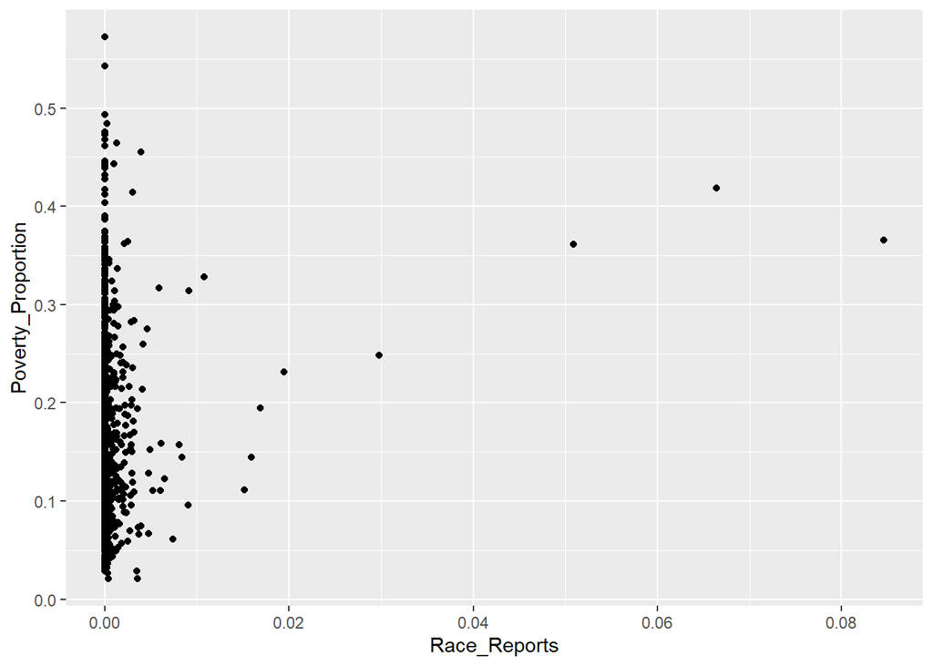

```r
project_data %>%
  ggplot(aes(Race_Reports, Poverty_Proportion)) +
  geom_point()
```

```r
cor.test(project_data$Race_Reports, project_data$Poverty_Proportion)
```

```
##
##  Pearson's product-moment correlation
##
## data:  project_data$Race_Reports and project_data$Poverty_Proportion
## t = 3.7577, df = 1092, p-value = 0.0001806
## alternative hypothesis: true correlation is not equal to 0
## 95 percent confidence interval:
##  0.05407794 0.17110767
## sample estimates:
##       cor
## 0.1129846
```

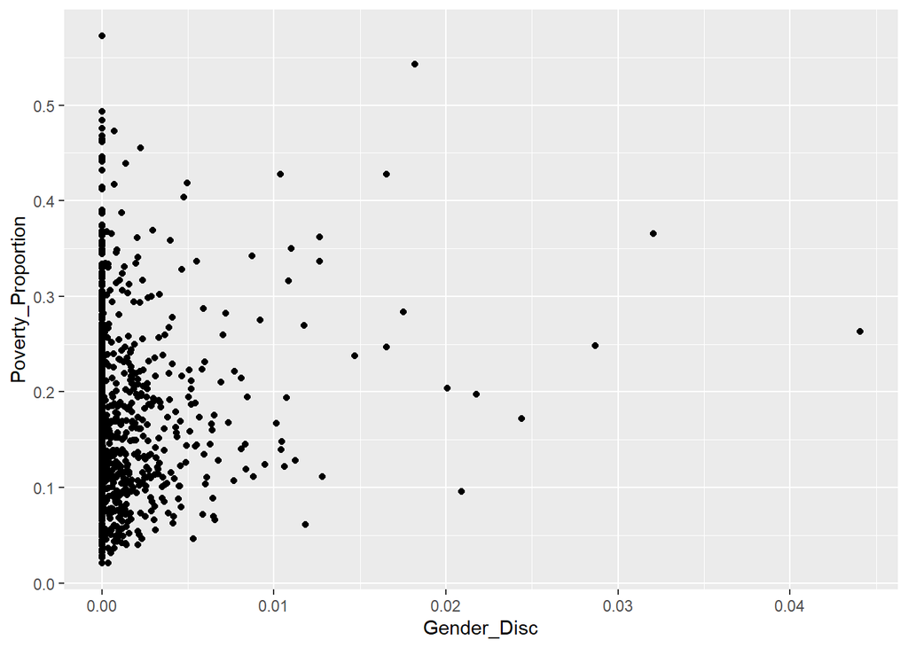

```r
project_data %>%
  ggplot(aes(Gender_Disc, Poverty_Proportion)) +
  geom_point()
```

```r
cor.test(project_data$Gender_Disc, project_data$Poverty_Proportion)
```

```
##
##  Pearson's product-moment correlation
##
## data:  project_data$Gender_Disc and project_data$Poverty_Proportion
## t = 3.4247, df = 1092, p-value = 0.0006383
## alternative hypothesis: true correlation is not equal to 0
## 95 percent confidence interval:
##  0.04408567 0.16136807
## sample estimates:
##       cor
## 0.1030852
```

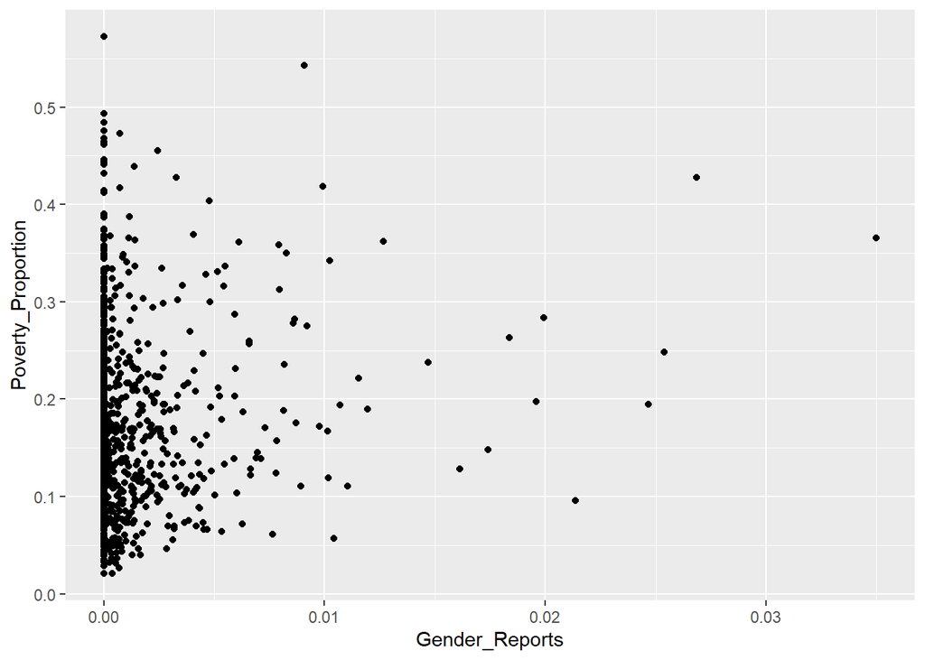

```r
project_data %>%
  ggplot(aes(Gender_Reports, Poverty_Proportion)) +
  geom_point()
```

```r
cor.test(project_data$Gender_Reports, project_data$Poverty_Proportion)
```

```
##
##  Pearson's product-moment correlation
##
## data:  project_data$Gender_Reports and project_data$Poverty_Proportion
## t = 3.787, df = 1092, p-value = 0.0001608
## alternative hypothesis: true correlation is not equal to 0
## 95 percent confidence interval:
##  0.05495556 0.17196201
## sample estimates:
##       cor
## 0.1138536
```

I will now run correlations on the different courses that are offered by districts.

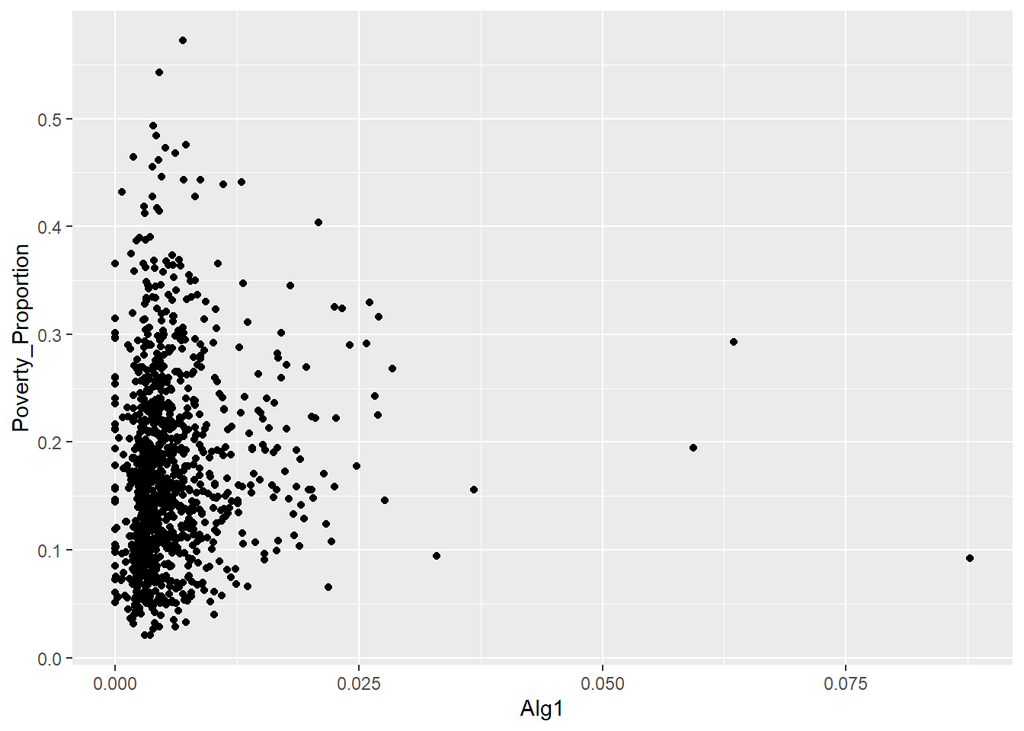

```r
project_data %>%
  ggplot(aes(Alg1, Poverty_Proportion)) +
  geom_point()
```

```r
cor.test(project_data$Alg1, project_data$Poverty_Proportion)
```

```
##
##  Pearson's product-moment correlation
##
## data:  project_data$Alg1 and project_data$Poverty_Proportion
## t = 3.3078, df = 1092, p-value = 0.0009708
## alternative hypothesis: true correlation is not equal to 0
## 95 percent confidence interval:
##  0.04057276 0.15793856
## sample estimates:
##        cor
## 0.09960208
```

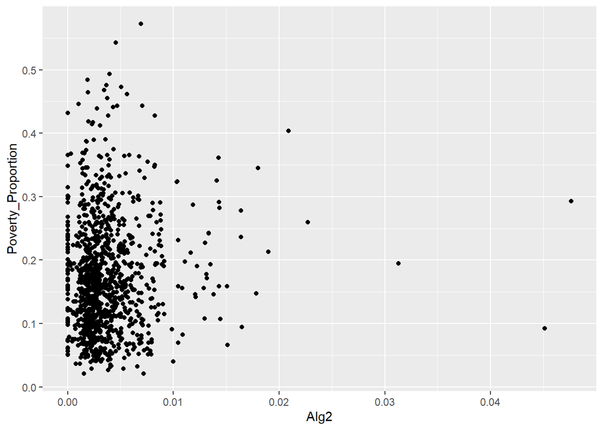

```r
project_data %>%
  ggplot(aes(Alg2, Poverty_Proportion)) +
  geom_point()
```

```r
cor.test(project_data$Alg2, project_data$Poverty_Proportion)
```

```
##
##  Pearson's product-moment correlation
##
## data:  project_data$Alg2 and project_data$Poverty_Proportion
## t = 2.7297, df = 1092, p-value = 0.00644
## alternative hypothesis: true correlation is not equal to 0
## 95 percent confidence interval:
##  0.02316934 0.14090644
## sample estimates:
##        cor
## 0.08232513
```

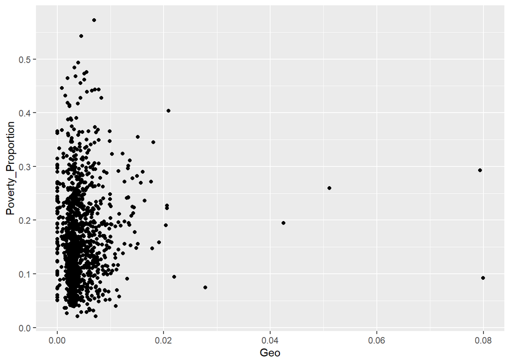

```r
project_data %>%
  ggplot(aes(Geo, Poverty_Proportion)) +
  geom_point()
```

```r
cor.test(project_data$Geo, project_data$Poverty_Proportion)
```

```
##
##  Pearson's product-moment correlation
##
## data:  project_data$Geo and project_data$Poverty_Proportion
## t = 2.0207, df = 1092, p-value = 0.04355
## alternative hypothesis: true correlation is not equal to 0
## 95 percent confidence interval:
##  0.00177297 0.11987060
## sample estimates:
##        cor
## 0.06103539
```

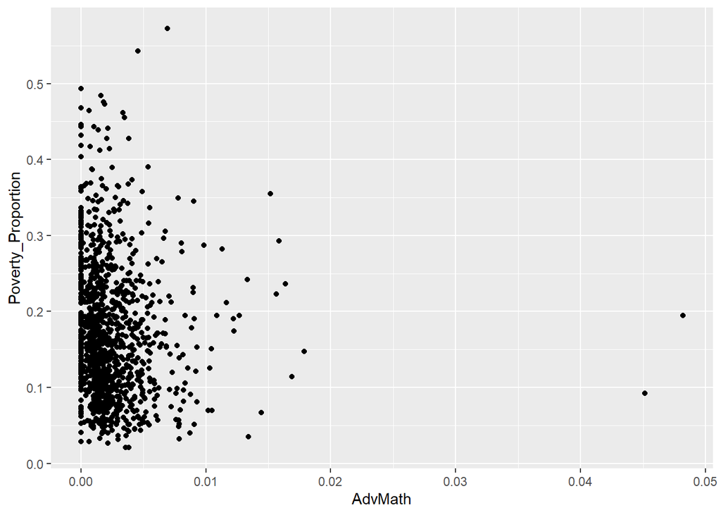

```r
project_data %>%
  ggplot(aes(AdvMath, Poverty_Proportion)) +
  geom_point()
```

```r
cor.test(project_data$AdvMath, project_data$Poverty_Proportion)
```

```
##
##  Pearson's product-moment correlation
##
## data:  project_data$AdvMath and project_data$Poverty_Proportion
## t = -2.7372, df = 1092, p-value = 0.006297
## alternative hypothesis: true correlation is not equal to 0
## 95 percent confidence interval:
##  -0.14112682 -0.02339407
## sample estimates:
##         cor
## -0.08254845
```

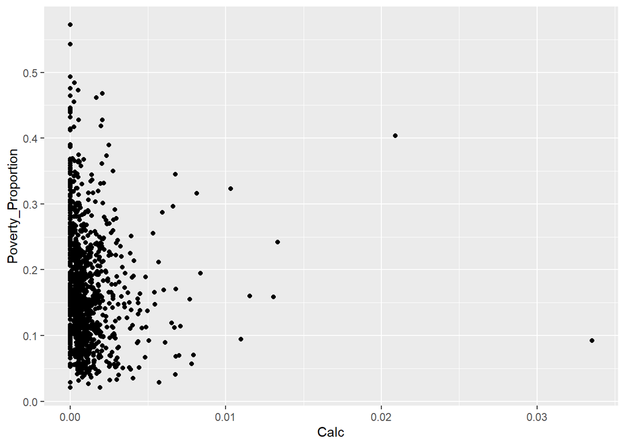

```r
project_data %>%
  ggplot(aes(Calc, Poverty_Proportion)) +
  geom_point()
```

```r
cor.test(project_data$Calc, project_data$Poverty_Proportion)
```

```
##
##  Pearson's product-moment correlation
##
## data:  project_data$Calc and project_data$Poverty_Proportion
## t = -2.8491, df = 1092, p-value = 0.004466
## alternative hypothesis: true correlation is not equal to 0
## 95 percent confidence interval:
##  -0.14443370 -0.02676764
## sample estimates:
##        cor
## -0.0859002
```

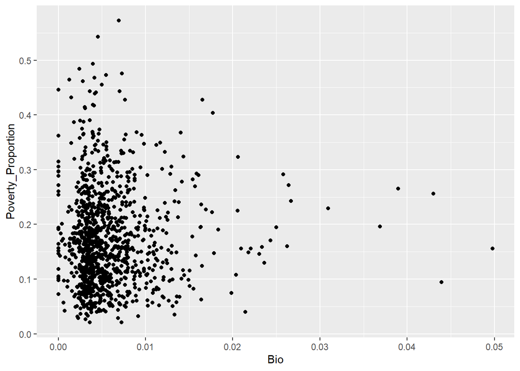

```r
project_data %>%
  ggplot(aes(Bio, Poverty_Proportion)) +
  geom_point()
```

```r
cor.test(project_data$Bio, project_data$Poverty_Proportion)
```

```
##
##  Pearson's product-moment correlation
##
## data:  project_data$Bio and project_data$Poverty_Proportion
## t = 0.67841, df = 1092, p-value = 0.4977
## alternative hypothesis: true correlation is not equal to 0
## 95 percent confidence interval:
##  -0.03879069  0.07969723
## sample estimates:
##        cor
## 0.02052534
```

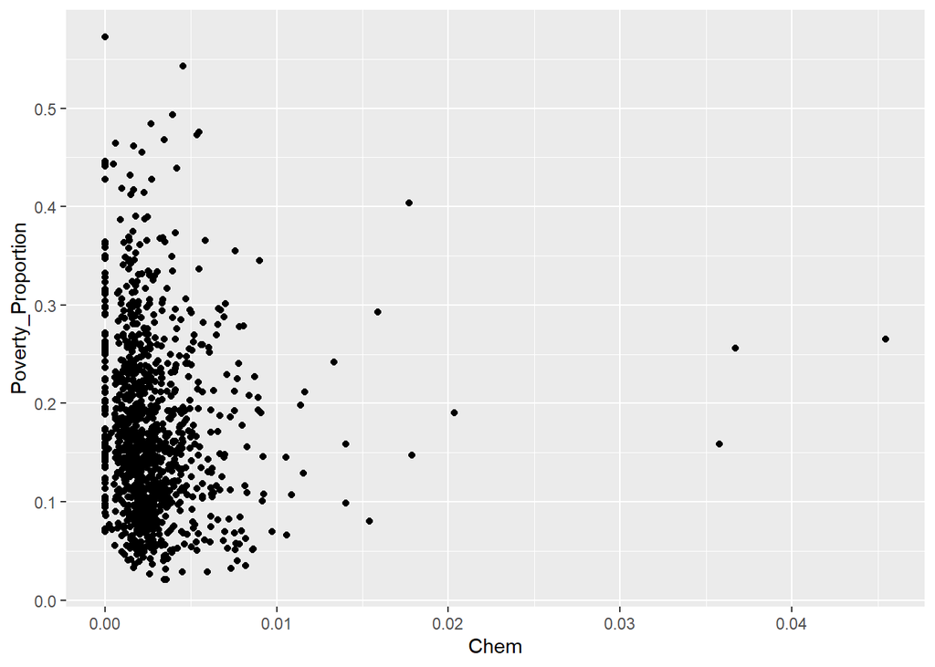

```r
project_data %>%
  ggplot(aes(Chem, Poverty_Proportion)) +
  geom_point()
```

```r
cor.test(project_data$Chem, project_data$Poverty_Proportion)
```

```
##
##  Pearson's product-moment correlation
##
## data:  project_data$Chem and project_data$Poverty_Proportion
## t = -1.6794, df = 1092, p-value = 0.09335
## alternative hypothesis: true correlation is not equal to 0
## 95 percent confidence interval:
##  -0.109695458  0.008537906
## sample estimates:
##         cor
## -0.05075662
```

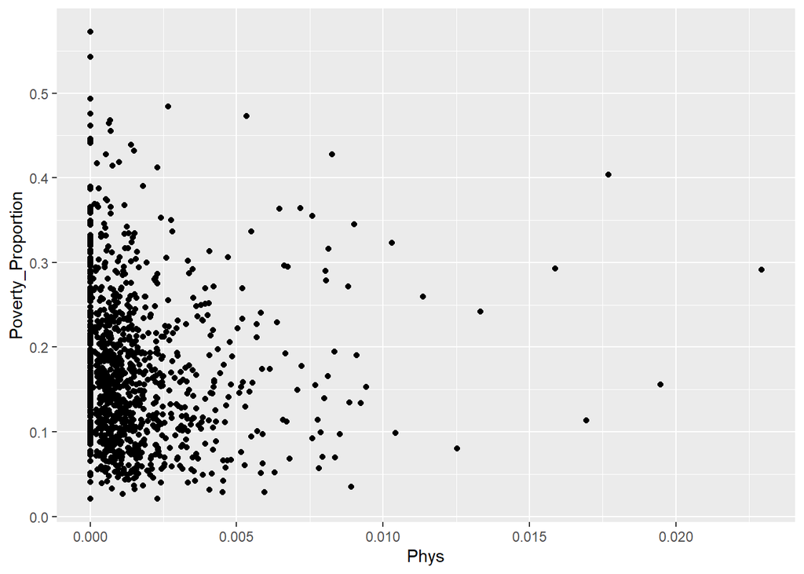

```r
project_data %>%
  ggplot(aes(Phys, Poverty_Proportion)) +
  geom_point()
```

```r
cor.test(project_data$Phys, project_data$Poverty_Proportion)
```

```
##
##  Pearson's product-moment correlation
##
## data:  project_data$Phys and project_data$Poverty_Proportion
## t = -1.3336, df = 1092, p-value = 0.1826
## alternative hypothesis: true correlation is not equal to 0
## 95 percent confidence interval:
##  -0.09935659  0.01898901
## sample estimates:
##         cor
## -0.04032521
```

I am going to look at the data for students that passed Algebra and the correlations.

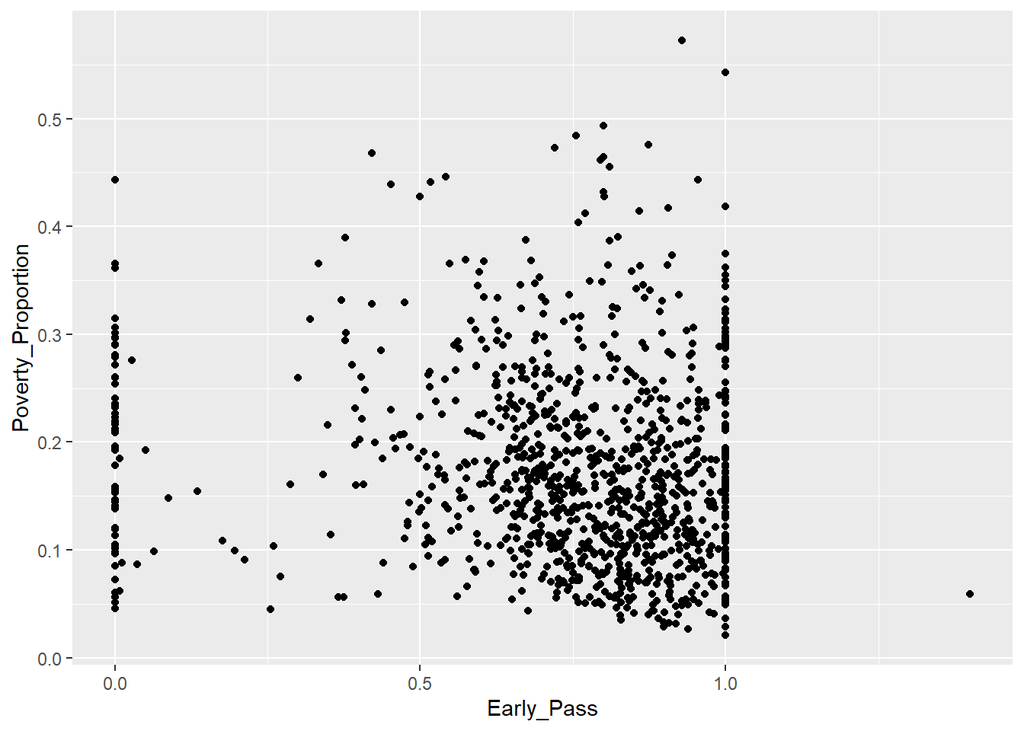

```r
project_data %>%
  ggplot(aes(Early_Pass, Poverty_Proportion)) +
  geom_point()
```

```r
cor.test(project_data$Early_Pass, project_data$Poverty_Proportion)
```

```
##
##  Pearson's product-moment correlation
##
## data:  project_data$Early_Pass and project_data$Poverty_Proportion
## t = -3.965, df = 1092, p-value = 7.818e-05
## alternative hypothesis: true correlation is not equal to 0
## 95 percent confidence interval:
##  -0.17714959 -0.06028841
## sample estimates:
##        cor
## -0.1191316
```

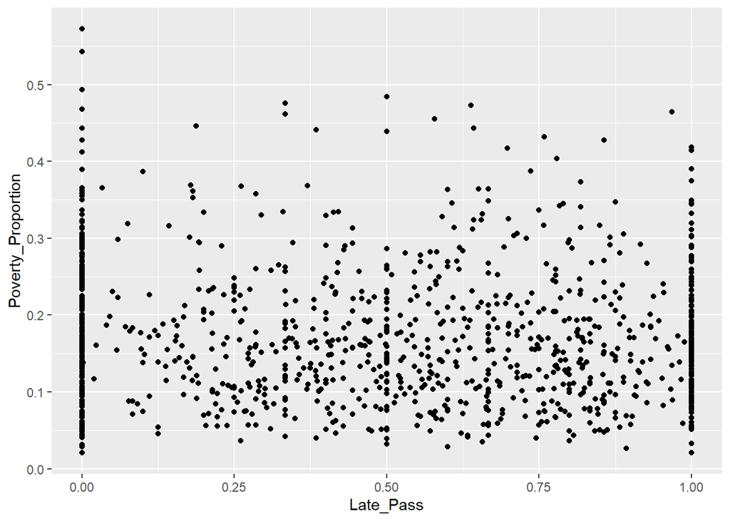

```r
project_data %>%
  ggplot(aes(Late_Pass, Poverty_Proportion)) +
  geom_point()
```

```r
cor.test(project_data$Late_Pass, project_data$Poverty_Proportion)
```

```
##
##  Pearson's product-moment correlation
##
## data:  project_data$Late_Pass and project_data$Poverty_Proportion
## t = -2.3956, df = 1092, p-value = 0.01676
## alternative hypothesis: true correlation is not equal to 0
## 95 percent confidence interval:
##  -0.13101187 -0.01309173
## sample estimates:
##         cor
## -0.07230447
```

Look at demographics and how they relate to poverty.

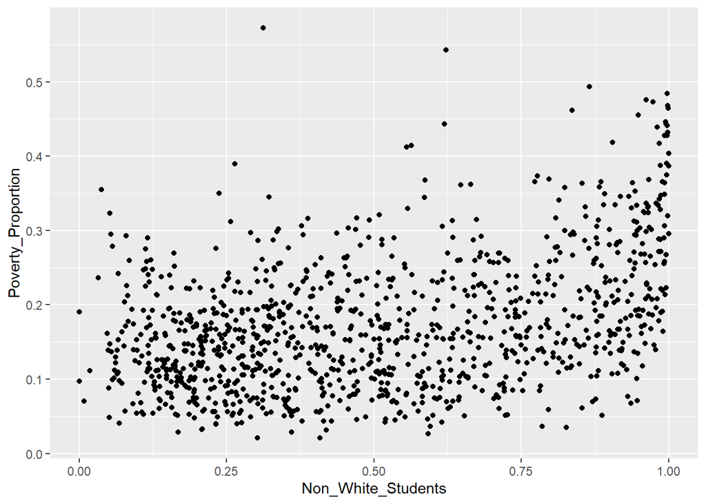

```r
project_data %>%
  ggplot(aes(Non_White_Students, Poverty_Proportion)) +
  geom_point()
```

```r
cor.test(project_data$Non_White_Students, project_data$Poverty_Proportion)
```

```
##
##  Pearson's product-moment correlation
##
## data:  project_data$Non_White_Students and project_data$Poverty_Proportion
## t = 14.535, df = 1092, p-value < 2.2e-16
## alternative hypothesis: true correlation is not equal to 0
## 95 percent confidence interval:
##  0.3517362 0.4511159
## sample estimates:
##       cor
## 0.4026118
```

Look at how grad rate and poverty relate and the correlation of it.

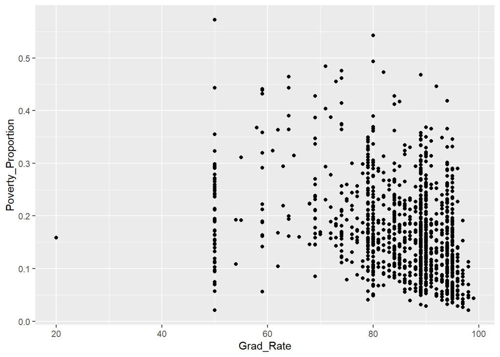

```r
project_data %>%
  ggplot(aes(Grad_Rate, Poverty_Proportion)) +
  geom_point()
```

```r
cor.test(project_data$Grad_Rate, project_data$Poverty_Proportion)
```

```
##
##  Pearson's product-moment correlation
##
## data:  project_data$Grad_Rate and project_data$Poverty_Proportion
## t = -9.9814, df = 1092, p-value < 2.2e-16
## alternative hypothesis: true correlation is not equal to 0
## 95 percent confidence interval:
##  -0.3425471 -0.2338881
## sample estimates:
##        cor
## -0.2891487
```